# project

## Variable 151

```r
##install.packages("checkmate")
##install.packages("acepack")
##install.packages("Hmisc")
##install.packages("pastecs")
##install.packages("psych")
```

```r
library(data.table)
data <- fread(file.choose(), stringsAsFactors = T)
head(data$x151)
```

```
## [1] 0 0 0 1 0 0
```

```r
## Summary of the data
summary(data$x151)
```

```
##    Min. 1st Qu.  Median    Mean 3rd Qu.    Max.
##  0.0000  0.0000  0.0000  0.2567  0.0000 44.0000
```

##Here we found that mean and median are not pretty close and we can say that the distribution of the variable is not approximately normal

##Missing Values: ##There are no missing values

##Description of the data

```r
#install.packages("psych")
library(psych)
describe(data$x151)
```

```
##    vars     n mean   sd median trimmed mad min max range skew kurtosis se
## X1    1 1e+05 0.26 1.28      0       0   0   0  44    44 8.31   102.01  0
```

## Here the kurtosis is very high positive hence there is large data in tail

```r
table(data$x151)
```

```
##
##     0     1     2     3     4     5     6     7     8     9    10    11
## 92426  2810  1322   924   758   413   293   241   237   143   118    69
##    12    13    14    15    16    17    18    19    20    21    22    23
##    62    38    37    25    22    11    18     6     2     5     7     1
##    24    25    26    27    28    31    32    34    44
##     2     1     1     2     1     1     2     1     1
```

```r
str(data$x151)
```

```
##  int [1:100000] 0 0 0 1 0 0 0 0 0 0 ...
```

## here the all values in integer

```r
##Total number of values excluding NA
NROW(data[which(data$x151<=2),])
```

```
## [1] 96558
```

##i.e;., 96%

```r
NROW(data[which(data$x151<=5),])
```

```
## [1] 98653
```

##i.e;.,98%

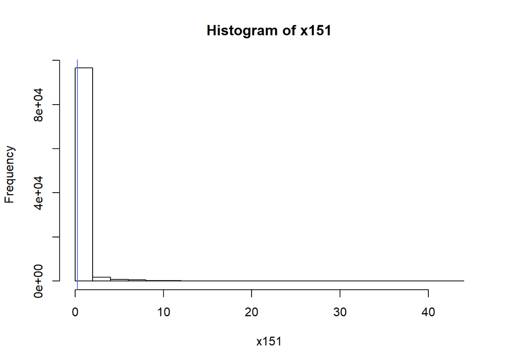

```r
##Now visualize the statistics
##Histogram

hist(data$x151,
    main = "Histogram of x151",
    xlab = "x151")
abline(v =mean(data$x151, na.rm = TRUE),col = "royalblue",
lwd = 1)
```

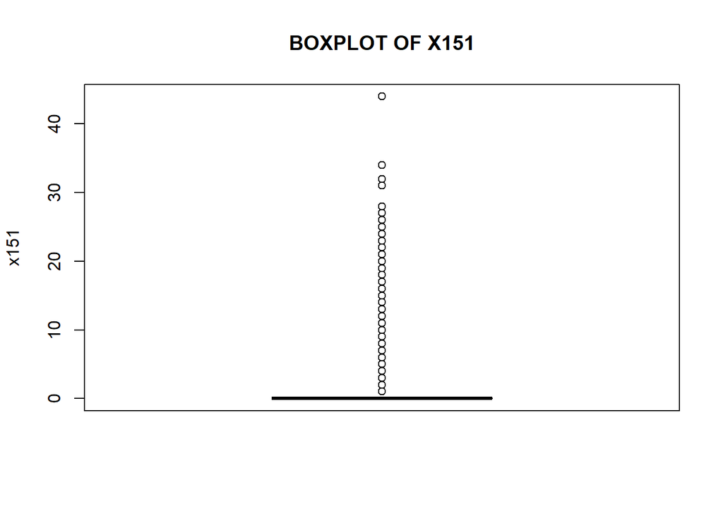

```r
##Boxplot
boxplot(data$x151,
       main = toupper("Boxplot of x151"),
       ylab = "x151",
       col = "blue")
```

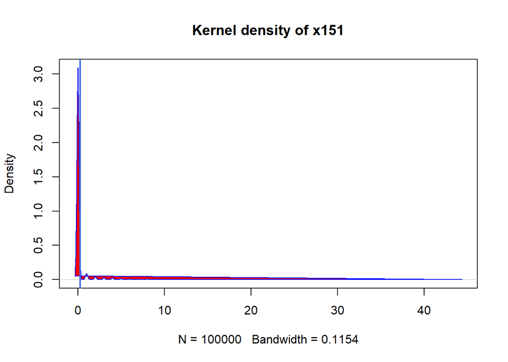

```r
##Density Plot
d <- density(data$x151, na.rm = TRUE)
plot(d, main = "Kernel density of x151")
polygon(d, col = "red", border = "blue")
abline(v =mean(data$x151, na.rm = TRUE),col = "royalblue",
lwd = 2)
```

## There is positive skewness in the data. There are no missing values. This variable have descrete values.

## Variable 152

```r
head(data$x152)
```

```
## [1] 0 0 0 1 0 0
```

```r
## Summary of the data
summary(data$x152)
```

```
##    Min. 1st Qu.  Median    Mean 3rd Qu.    Max.
##  0.0000  0.0000  0.0000  0.3004  0.0000 54.0000
```

##Here we found that mean and median are not pretty close and we can say that the distribution of the variable is not approximately normal

##Missing Values: ##There are no missing values

##Description of the data

```r
#install.packages("psych")


describe(data$x152)
```

```
##    vars     n mean   sd median trimmed mad min max range skew kurtosis se
## X1    1 1e+05  0.3 1.46      0       0   0   0  54    54 8.47   110.55  0
```

## Here the kurtosis is very high positive hence there is large data in tail

```r
table(data$x152)
```

```
##
##     0     1     2     3     4     5     6     7     8     9    10    11
## 91600  3072  1428   994   812   478   341   268   244   181   134   103
##    12    13    14    15    16    17    18    19    20    21    22    23
##    73    53    49    47    27    18    17    11     7     5     5     5
##    24    25    26    27    28    29    30    31    32    33    34    36
##     2     6     3     1     1     3     2     1     1     1     5     1
##    54
##     1
```

```r
str(data$x152)
```

```
##  int [1:100000] 0 0 0 1 0 0 0 0 0 0 ...
```

## here the all values in integer

```r
##Total number of values excluding NA
NROW(data[which(data$x152<=2),])
```

```
## [1] 96100
```

##i.e;., 96%

```r
NROW(data[which(data$x152<=5),])
```

```
## [1] 98384
```

##i.e;.,98%

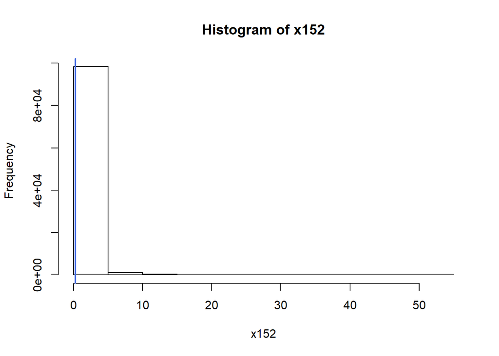

```r
##Now visualize the statistics
##Histogram

hist(data$x152,
    main = "Histogram of x152",
    xlab = "x152")
abline(v =mean(data$x152, na.rm = TRUE),col = "royalblue",
lwd = 2)
```

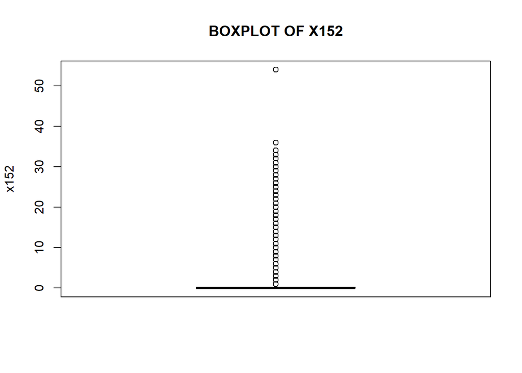

```r
##Boxplot
boxplot(data$x152,
       main = toupper("Boxplot of x152"),
       ylab = "x152",
       col = "blue")
```

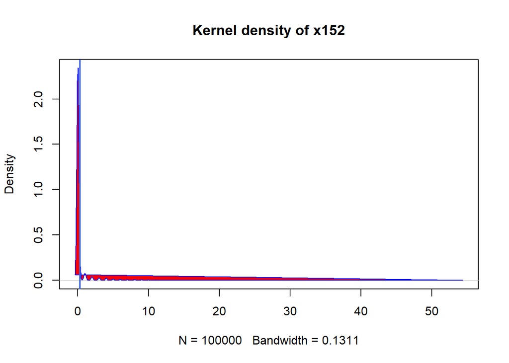

```r
##Density Plot
d <- density(data$x152, na.rm = TRUE)
plot(d, main = "Kernel density of x152")
polygon(d, col = "red", border = "blue")
abline(v =mean(data$x152, na.rm = TRUE),col = "royalblue",
lwd = 2)
```

## There is positive skewness in the data. There are no missing values. This variable have descrete values.

## Variable 153

```r
head(data$x153)
```

```
## [1] 0 0 0 1 0 0
```

```r
## Summary of the data
summary(data$x153)
```

```
##    Min. 1st Qu.  Median    Mean 3rd Qu.    Max.
##  0.0000  0.0000  0.0000  0.3299  0.0000 54.0000
```

##Here we found that mean and median are not pretty close and we can say that the distribution of the variable is not approximately normal

##Missing Values: ##There are no missing values

##Description of the data

```r
#install.packages("psych")


describe(data$x153)
```

```
##    vars     n mean   sd median trimmed mad min max range skew kurtosis
## X1    1 1e+05 0.33 1.59      0       0   0   0  54    54 8.88   124.59
##      se
## X1 0.01
```

## Here the kurtosis is very high positive hence there is large data in tail

```r
table(data$x153)
```

```
##
##     0     1     2     3     4     5     6     7     8     9    10    11
## 91069  3227  1513  1049   847   506   355   306   264   197   145   106
##    12    13    14    15    16    17    18    19    20    21    22    23
##    87    67    46    50    29    22    24    17     7     9    12     6
##    24    25    26    27    28    29    30    31    32    33    34    35
##     4     4     2     1     2     5     5     1     2     1     3     1
##    36    37    39    46    54
##     2     1     2     3     1
```

```r
str(data$x153)
```

```
##  int [1:100000] 0 0 0 1 0 0 0 0 0 0 ...
```

```r
class(data$x153)
```

```
## [1] "integer"
```

## here the all values in integer

```r
##Total number of values excluding NA
NROW(data[which(data$x153<=2),])
```

```
## [1] 95809
```

##i.e;., 96%

```r
NROW(data[which(data$x153<=5),])
```

```
## [1] 98211
```

##i.e;.,98%

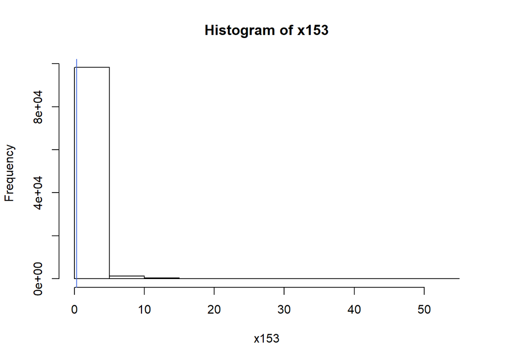

```r
##Now visualize the statistics
##Histogram

hist(data$x153,
    main = "Histogram of x153",
    xlab = "x153")
abline(v =mean(data$x153, na.rm = TRUE),col = "royalblue",
lwd = 1)
```

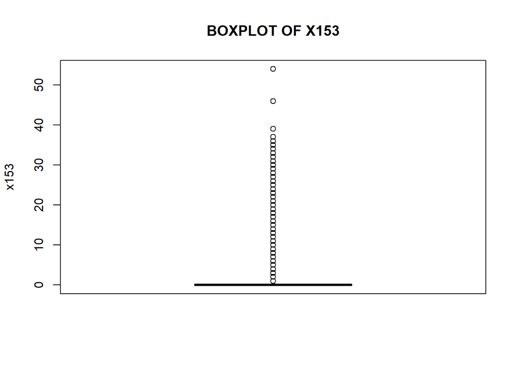

```r
##Boxplot
boxplot(data$x153,
       main = toupper("Boxplot of x153"),
       ylab = "x153",
       col = "blue")
```

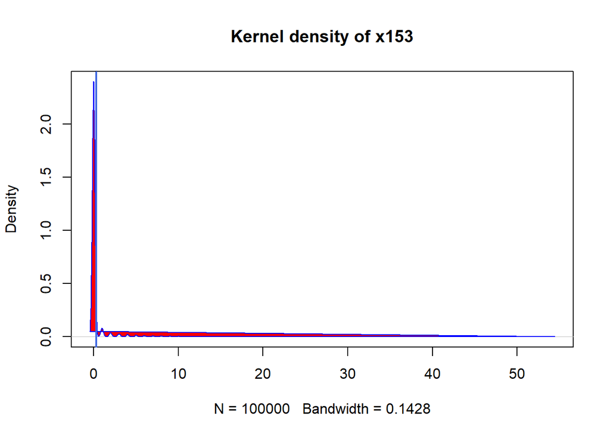

```r
##Density Plot
d <- density(data$x153, na.rm = TRUE)
plot(d, main = "Kernel density of x153")
polygon(d, col = "red", border = "blue")
abline(v =mean(data$x153, na.rm = TRUE),col = "royalblue",
lwd = 2)
```

## There is positive skewness in the data. There are no missing values. This variable have descrete values.

## Variable 154

```r
head(data$x154)
```

```
## [1] 0 0 0 0 0 0
```

```r
## Summary of the data
summary(data$x154)
```

```
##    Min. 1st Qu.  Median    Mean 3rd Qu.    Max.
## 0.00000 0.00000 0.00000 0.01325 0.00000 1.00000
```

##Here we found that mean and median are not pretty close and we can say that the distribution of the variable is not approximately normal

##Missing Values: ##There are no missing values

##Description of the data

```r
#install.packages("psych")


describe(data$x154)
```

```
##    vars     n mean   sd median trimmed mad min max range skew kurtosis se
## X1    1 1e+05 0.01 0.11      0       0   0   0   1     1 8.51    70.48  0
```

## Here the kurtosis is very high positive hence there is large data in tail

```r
table(data$x154)
```

```
##
##     0     1
## 98675  1325
```

```r
str(data$x154)
```

```
##  int [1:100000] 0 0 0 0 0 0 0 0 0 0 ...
```

```r
class(data$x54)
```

```
## [1] "NULL"
```

## here the all values in integer

```r
##Total number of values excluding NA
NROW(data[which(data$x154<=2),])
```

```
## [1] 100000
```

```r
NROW(data[which(data$x154<=5),])
```

```
## [1] 100000
```

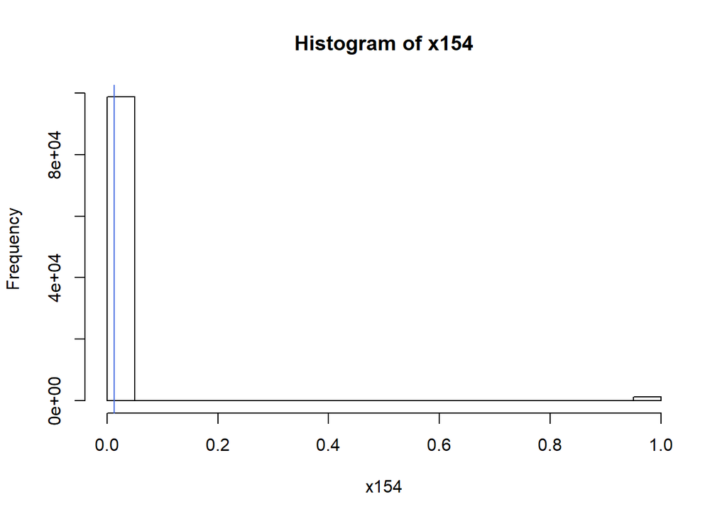

```r
##Now visualize the statistics
##Histogram

hist(data$x154,
    main = "Histogram of x154",
    xlab = "x154")
abline(v =mean(data$x154, na.rm = TRUE),col = "royalblue",
lwd = 1)
```

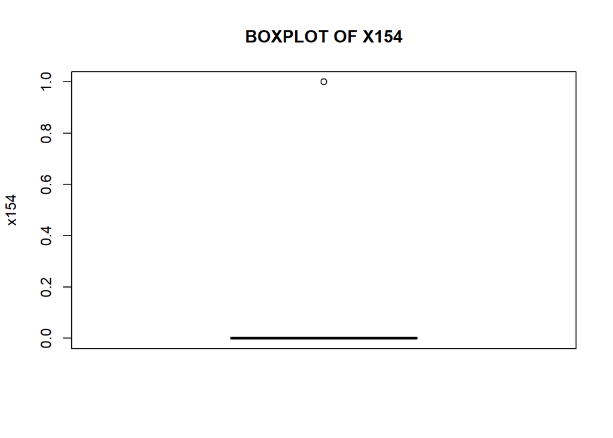

```r
##Boxplot
boxplot(data$x154,
       main = toupper("Boxplot of x154"),
       ylab = "x154",
       col = "blue")
```

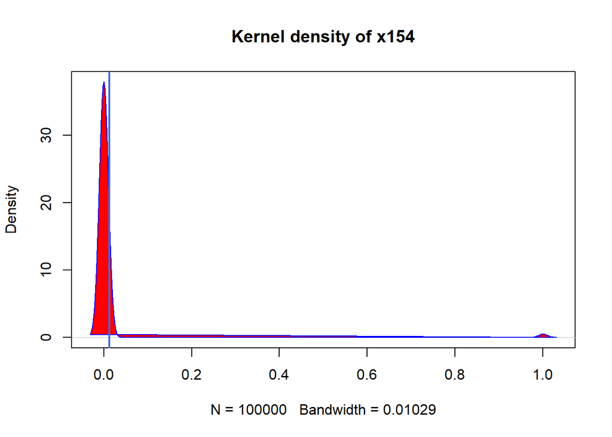

```r
##Density Plot
d <- density(data$x154, na.rm = TRUE)
plot(d, main = "Kernel density of x154")
polygon(d, col = "red", border = "blue")
abline(v =mean(data$x154, na.rm = TRUE),col = "royalblue",
lwd = 2)
```

## There is positive skewness in the data. There are no missing values. This variable have descrete binomial values.

## Variable 155

```r
head(data$x155)
```

```
## [1] NA NA NA NA NA NA
```

```r
## Summary of the data
summary(data$x155)
```

```
##    Min. 1st Qu.  Median    Mean 3rd Qu.    Max.    NA's
##    1.00    1.00    1.00    1.47    1.00    9.00   79051
```

##Here we found that mean and median are not pretty close and we can say that the distribution of the variable is not approximately normal

##Description of the data

```r
#install.packages("psych")


describe(data$x155)
```

```
##    vars     n mean  sd median trimmed mad min max range skew kurtosis   se
## X1    1 20949 1.47 1.2      1    1.11   0   1   9     8 2.64     6.02 0.01
```

## Here the kurtosis is very high positive hence there is large data in tail

```r
table(data$x155)
```

```
##
##     1     2     3     4     5     7     9
## 17281  1239   506   334  1422   165     2
```

```r
str(data$x155)
```

```
##  int [1:100000] NA NA NA NA NA NA NA NA NA NA ...
```

```r
class(data$x155)
```

```
## [1] "integer"
```

## here the all values in integer

```r
##Total number of values excluding NA
NROW(data[which(data$x155<=2),])
```

```
## [1] 18520
```

```r
NROW(data[which(data$x155<=5),])
```

```
## [1] 20782
```

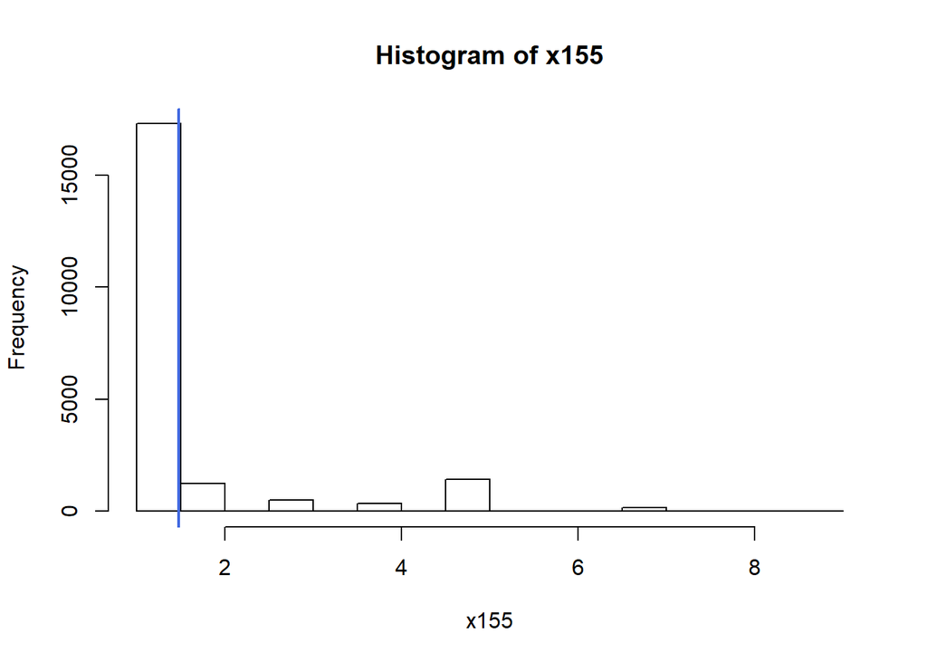

```r
##Now visualize the statistics
##Histogram

hist(data$x155,
    main = "Histogram of x155",
    xlab = "x155")
abline(v =mean(data$x155, na.rm = TRUE),col = "royalblue",
lwd = 2)
```

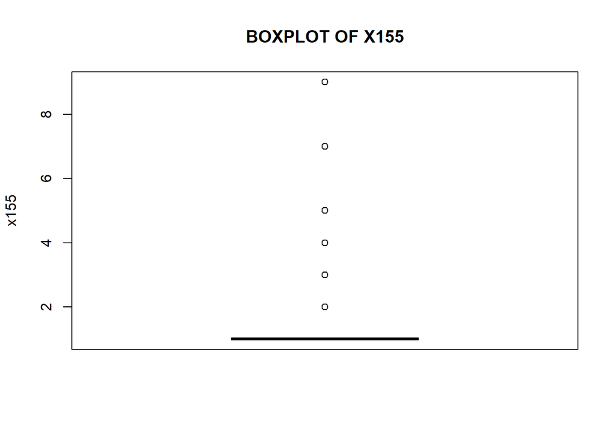

```r
##Boxplot
boxplot(data$x155,
       main = toupper("Boxplot of x155"),
       ylab = "x155",
       col = "blue")
```

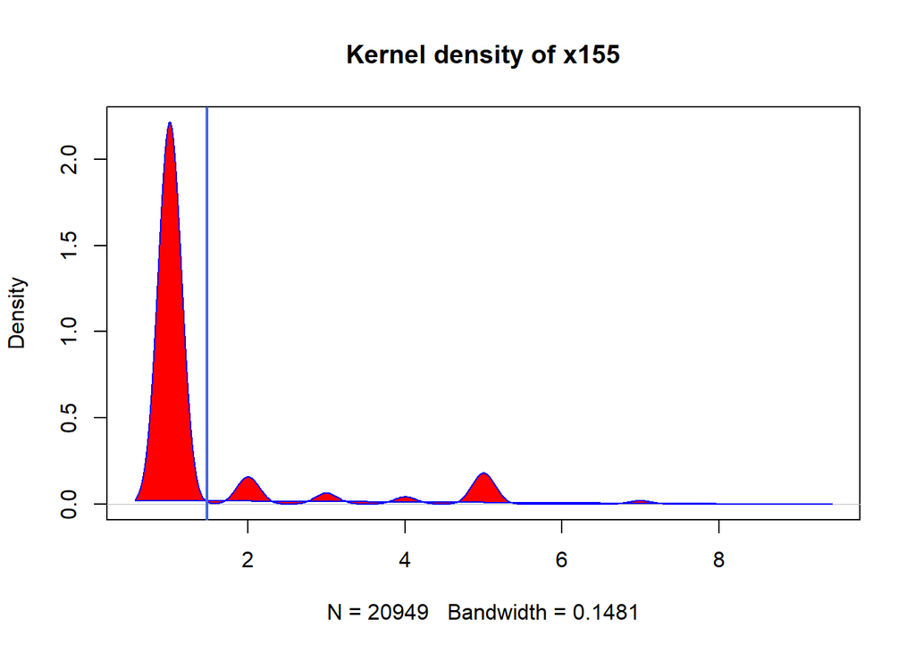

```r
##Density Plot
d <- density(data$x155, na.rm = TRUE)
plot(d, main = "Kernel density of x155")
polygon(d, col = "red", border = "blue")
abline(v =mean(data$x155, na.rm = TRUE),col = "royalblue",
lwd = 2)
```

## Variable 156

```r
head(data$x156)
```

```
## [1] 0 0 0 0 0 0
```

```r
## Summary of the data
summary(data$x156)
```

```
##     Min.  1st Qu.   Median     Mean  3rd Qu.     Max.
##  0.00000  0.00000  0.00000  0.03969  0.00000 11.00000
```

##Here we found that mean and median are not pretty close and we can say that the distribution of the variable is not approximately normal

##Missing Values: ##There are no missing values

##Description of the data

```r
#install.packages("psych")


describe(data$x156)
```

```
##    vars     n mean   sd median trimmed mad min max range  skew kurtosis se
## X1    1 1e+05 0.04 0.36      0       0   0   0  11    11 10.77   133.84  0
```

## Here the kurtosis is very high positive hence there is large data in tail

```r
table(data$x156)
```

```
##
##     0     1     2     3     4     5     6     7     8    11
## 98511   406   264   363   409     8    17    11    10     1
```

```r
str(data$x156)
```

```
##  int [1:100000] 0 0 0 0 0 0 0 0 0 0 ...
```

```r
class(data$x156)
```

```
## [1] "integer"
```

## here the all values in integer

```r
##Total number of values excluding NA
NROW(data[which(data$x156<=2),])
```

```
## [1] 99181
```

```r
NROW(data[which(data$x156<=5),])
```

```
## [1] 99961
```

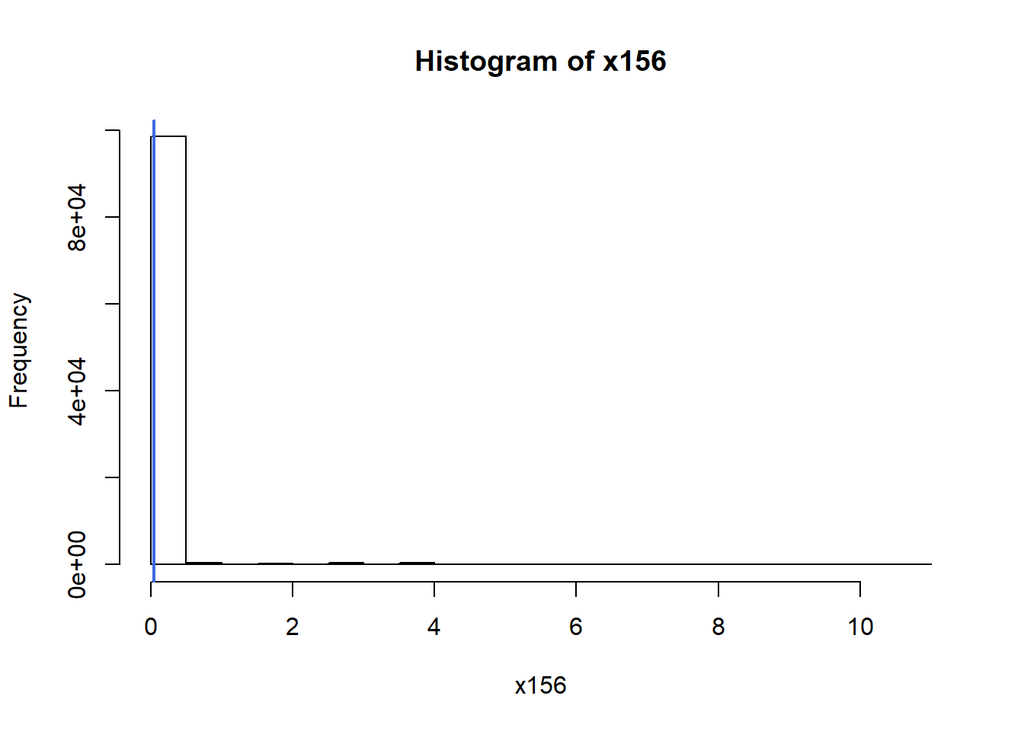

```r
##Now visualize the statistics
##Histogram

hist(data$x156,
    main = "Histogram of x156",
    xlab = "x156")
abline(v =mean(data$x156, na.rm = TRUE),col = "royalblue",
lwd = 2)
```

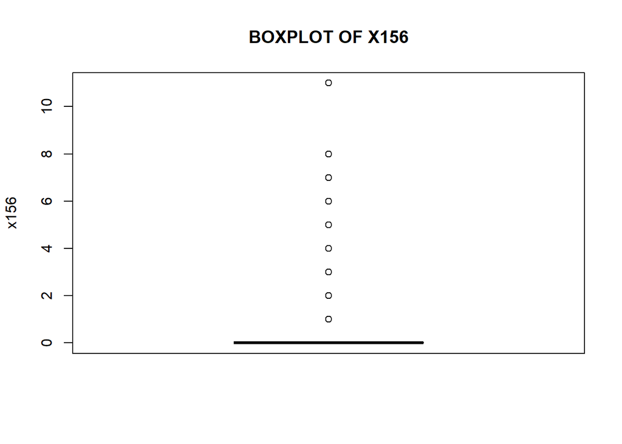

```r
##Boxplot
boxplot(data$x156,
       main = toupper("Boxplot of x156"),
       ylab = "x156",
       col = "blue")
```

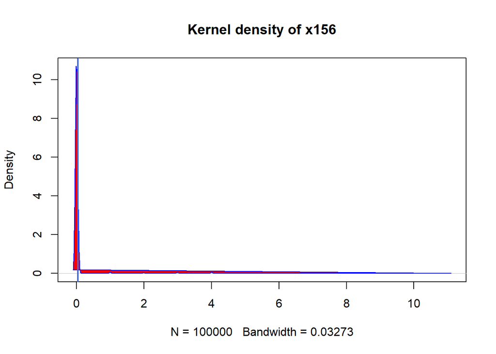

```r
##Density Plot
d <- density(data$x156, na.rm = TRUE)
plot(d, main = "Kernel density of x156")
polygon(d, col = "red", border = "blue")
abline(v =mean(data$x156, na.rm = TRUE),col = "royalblue",
lwd = 2)
```

## There is positive skewness in the data. There are no missing values. This variable have descrete values.

## Variable 157

```r
head(data$x157)
```

```
## [1] 0 0 0 0 0 0
```

```r
## Summary of the data
summary(data$x157)
```

```
##     Min.  1st Qu.   Median     Mean  3rd Qu.     Max.
##  0.00000  0.00000  0.00000  0.09872  0.00000 29.00000
```

##Here we found that mean and median are not pretty close and we can say that the distribution of the variable is not approximately normal

##Missing Values: ##There are no missing values

##Description of the data

```r
#install.packages("psych")

describe(data$x157)
```

```
##    vars     n mean   sd median trimmed mad min max range  skew kurtosis se
## X1    1 1e+05  0.1 0.85      0       0   0   0  29    29 10.84   142.49  0
```

## Here the kurtosis is very high positive hence there is large data in tail

```r
table(data$x157)
```

```
##
##     0     1     2     3     4     5     6     7     8     9    10    11
## 97995   432   238   197   180   145   163   130   121   159   201     5
##    12    13    14    15    16    18    19    20    29
##     2     4     4     3     4     4     6     6     1
```

```r
str(data$x157)
```

```
##  int [1:100000] 0 0 0 0 0 0 0 0 0 0 ...
```

```r
class(data$x157)
```

```
## [1] "integer"
```

## here the all values in integer

```r
##Total number of values excluding NA
NROW(data[which(data$x157<=2),])
```

```
## [1] 98665
```

```r
NROW(data[which(data$x157<=5),])
```

```
## [1] 99187
```

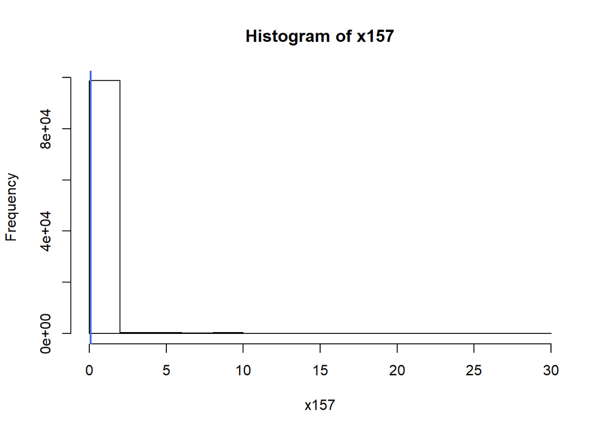

```r
##Now visualize the statistics
##Histogram

hist(data$x157,
    main = "Histogram of x157",
    xlab = "x157")
abline(v =mean(data$x157, na.rm = TRUE),col = "royalblue",
lwd = 2)
```

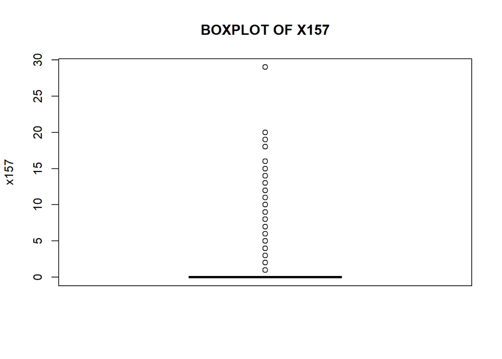

```r
##Boxplot
boxplot(data$x157,
       main = toupper("Boxplot of x157"),
       ylab = "x157",
       col = "blue")
```

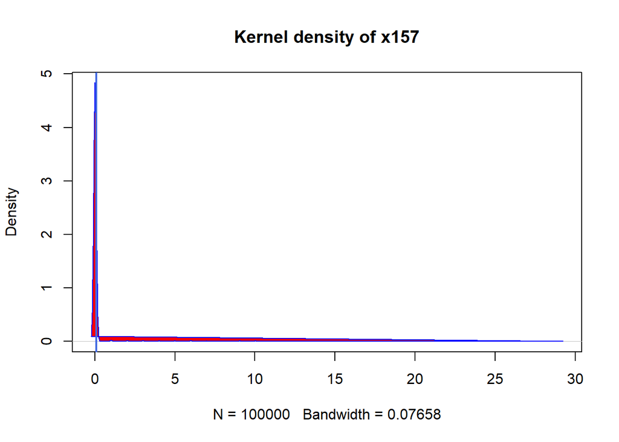

```r
##Density Plot
d <- density(data$x157, na.rm = TRUE)
plot(d, main = "Kernel density of x157")
polygon(d, col = "red", border = "blue")
abline(v =mean(data$x157, na.rm = TRUE),col = "royalblue",
lwd = 2)
```

## There is positive skewness in the data. There are no missing values. This variable have descrete values.

## Variable 158

```r
head(data$x158)
```

```
## [1] 0 0 0 0 0 0
```

```r
## Summary of the data
summary(data$x158)
```

```
##    Min. 1st Qu.  Median    Mean 3rd Qu.    Max.
##  0.0000  0.0000  0.0000  0.2031  0.0000 61.0000
```

##Here we found that mean and median are not pretty close and we can say that the distribution of the variable is not approximately normal

##Missing Values: ##There are no missing values

##Description of the data

```r
#install.packages("psych")

describe(data$x158)
```

```
##    vars     n mean   sd median trimmed mad min max range  skew kurtosis
## X1    1 1e+05  0.2 1.67      0       0   0   0  61    61 11.07   157.09
##      se
## X1 0.01
```

## Here the kurtosis is very high positive hence there is large data in tail

```r
table(data$x158)
```

```
##
##     0     1     2     3     4     5     6     7     8     9    10    11
## 97439   483   235   192   161   136   162   113   108    90    95    84
##    12    13    14    15    16    17    18    19    20    21    22    23
##    83    90    66    61    60    49    58    34    42    68    58     3
##    24    26    27    28    29    30    31    33    34    35    36    37
##     2     1     2     3     2     4     1     1     1     1     1     1
##    38    40    41    42    44    48    49    61
##     1     1     1     3     1     1     1     1
```

```r
str(data$x158)
```

```
##  int [1:100000] 0 0 0 0 0 0 0 0 0 0 ...
```

```r
class(data$x158)
```

```
## [1] "integer"
```

## here the all values in integer

```r
##Total number of values excluding NA
NROW(data[which(data$x158<=2),])
```

```
## [1] 98157
```

```r
NROW(data[which(data$x158<=5),])
```

```
## [1] 98646
```

##i.e;.,98%

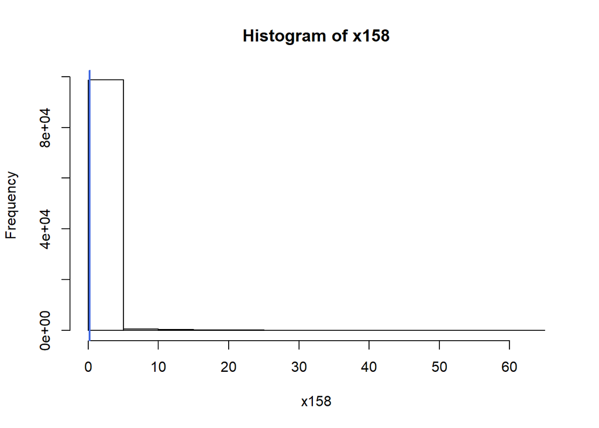

```r
##Now visualize the statistics
##Histogram

hist(data$x158,
    main = "Histogram of x158",
    xlab = "x158")
abline(v =mean(data$x158, na.rm = TRUE),col = "royalblue",
lwd = 2)
```

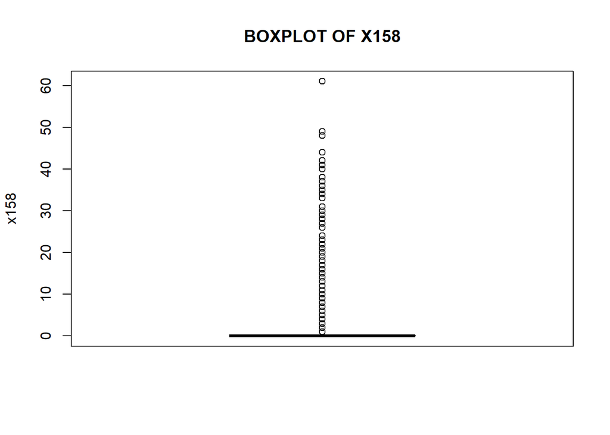

```r
##Boxplot
boxplot(data$x158,
       main = toupper("Boxplot of x158"),
       ylab = "x158",
       col = "blue")
```

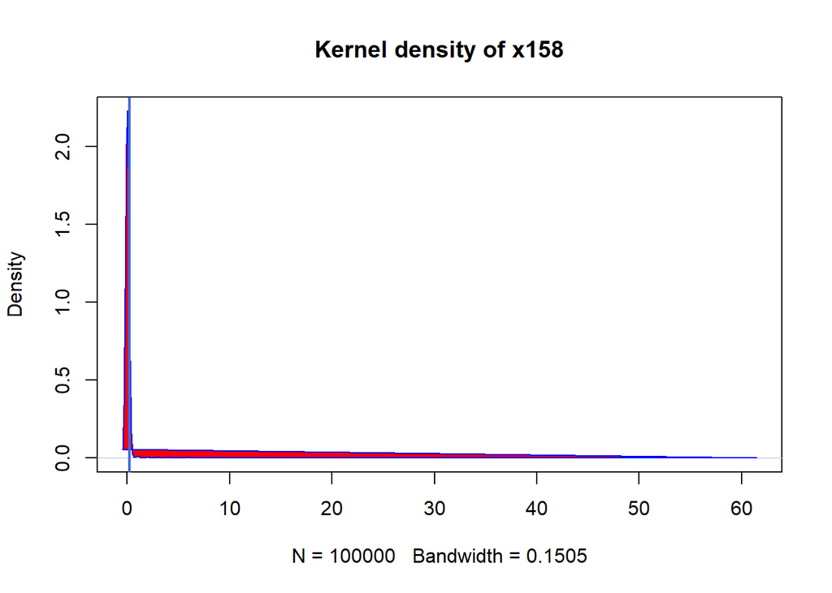

```r
##Density Plot
d <- density(data$x158, na.rm = TRUE)
plot(d, main = "Kernel density of x158")
polygon(d, col = "red", border = "blue")
abline(v =mean(data$x158, na.rm = TRUE),col = "royalblue",
lwd = 2)
```

## There is positive skewness in the data. There are no missing values. This variable have descrete values.

## Variable 159

```r
head(data$x159)
```

```
## [1] 0 0 0 0 0 0
```

```r
## Summary of the data
summary(data$x159)
```

```
##    Min. 1st Qu.  Median    Mean 3rd Qu.    Max.
##  0.0000  0.0000  0.0000  0.3028  0.0000 92.0000
```

##Here we found that mean and median are not pretty close and we can say that the distribution of the variable is not approximately normal

##Missing Values: ##There are no missing values

##Description of the data

```r
#install.packages("psych")

describe(data$x159)
```

```
##    vars     n mean   sd median trimmed mad min max range  skew kurtosis
## X1    1 1e+05  0.3 2.41      0       0   0   0  92    92 11.17   164.85
##      se
## X1 0.01
```

## Here the kurtosis is very high positive hence there is large data in tail

```r
table(data$x159)
```

```
##
##     0     1     2     3     4     5     6     7     8     9    10    11
## 97012   511   267   207   165   149   149   129   108   107    87    87
##    12    13    14    15    16    17    18    19    20    21    22    23
##    84    72    62    69    67    57    51    67    33    40    33    48
##    24    25    26    27    28    29    30    31    32    33    34    35
##    25    37    36    34    39    18    25    15    23    30    26     3
##    36    38    39    40    41    43    44    46    47    51    54    56
##     1     2     2     2     2     2     2     1     2     2     2     1
##    57    59    66    68    69    81    92
##     1     1     1     1     1     1     1
```

```r
str(data$x159)
```

```
##  int [1:100000] 0 0 0 0 0 0 0 0 0 0 ...
```

```r
class(data$x159)
```

```
## [1] "integer"
```

## here the all values in integer

```r
##Total number of values excluding NA
NROW(data[which(data$x159<=2),])
```

```
## [1] 97790
```

```r
NROW(data[which(data$x159<=5),])
```

```
## [1] 98311
```

##i.e;.,98%

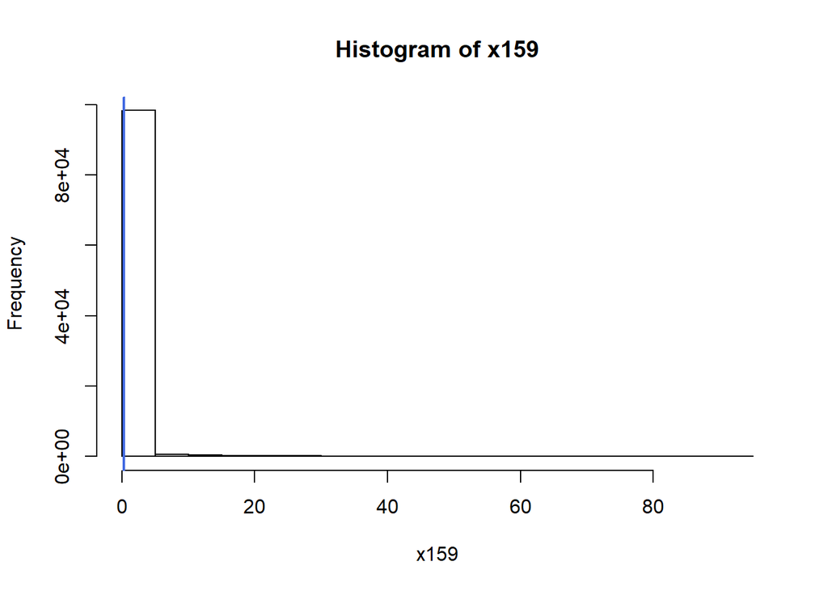

```r
##Now visualize the statistics
##Histogram

hist(data$x159,
    main = "Histogram of x159",
    xlab = "x159")
abline(v =mean(data$x159, na.rm = TRUE),col = "royalblue",
lwd = 2)
```

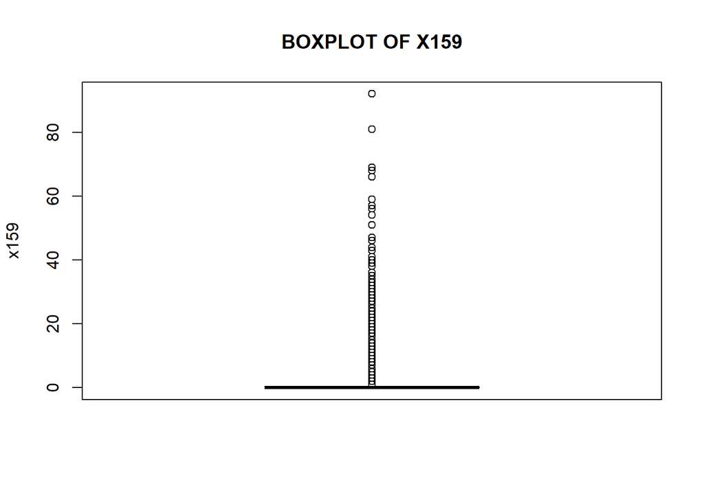

```r
##Boxplot
boxplot(data$x159,
       main = toupper("Boxplot of x159"),
       ylab = "x159",
       col = "blue")
```

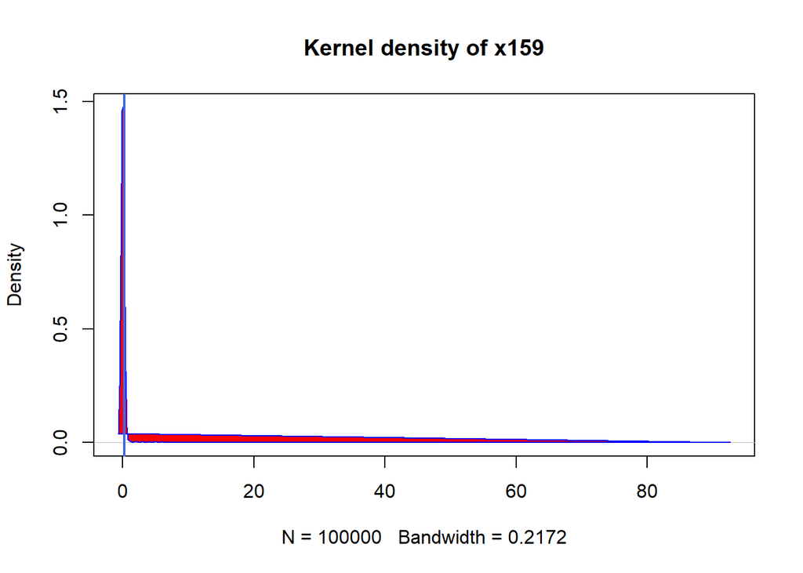

```r
##Density Plot
d <- density(data$x159, na.rm = TRUE)
plot(d, main = "Kernel density of x159")
polygon(d, col = "red", border = "blue")
abline(v =mean(data$x159, na.rm = TRUE),col = "royalblue",
lwd = 2)
```

## There is positive skewness in the data. There are no missing values. This variable have descrete values.

## Variable 160

```r
head(data$x160)
```

```
## [1] 0 0 0 0 0 0
```

```r
## Summary of the data
summary(data$x160)
```

```
##     Min.  1st Qu.   Median     Mean  3rd Qu.     Max.
##   0.0000   0.0000   0.0000   0.3934   0.0000 112.0000
```

##Here we found that mean and median are not pretty close and we can say that the distribution of the variable is not approximately normal

##Missing Values: ##There are no missing values

##Description of the data

```r
#install.packages("psych")

describe(data$x160)
```

```
##    vars     n mean   sd median trimmed mad min max range  skew kurtosis
## X1    1 1e+05 0.39 3.06      0       0   0   0 112   112 11.17   164.86
##      se
## X1 0.01
```

## Here the kurtosis is very high positive hence there is large data in tail

```r
table(data$x160)
```

```
##
##     0     1     2     3     4     5     6     7     8     9    10    11
## 96669   539   280   211   177   159   150   137   125   118   102    91
##    12    13    14    15    16    17    18    19    20    21    22    23
##    96    77    69    71    61    58    44    44    53    43    24    48
##    24    25    26    27    28    29    30    31    32    33    34    35
##    36    40    35    43    37    34    34    30    26    17    18    15
##    36    37    38    39    40    41    42    43    44    45    46    47
##    23    19    19    14    10    14    14     5     8    21    11     2
##    48    50    51    52    54    55    56    57    59    60    61    63
##     1     1     2     1     1     2     3     1     3     1     1     1
##    64    66    68    76    78    90    92   102   112
##     2     2     1     1     1     1     1     1     1
```

```r
str(data$x160)
```

```
##  int [1:100000] 0 0 0 0 0 0 0 0 0 0 ...
```

```r
class(data$x160)
```

```
## [1] "integer"
```

## here the all values in integer

```r
##Total number of values excluding NA
NROW(data[which(data$x160<=2),])
```

```
## [1] 97488
```

```r
NROW(data[which(data$x160<=5),])
```

```
## [1] 98035
```

##i.e;.,98%

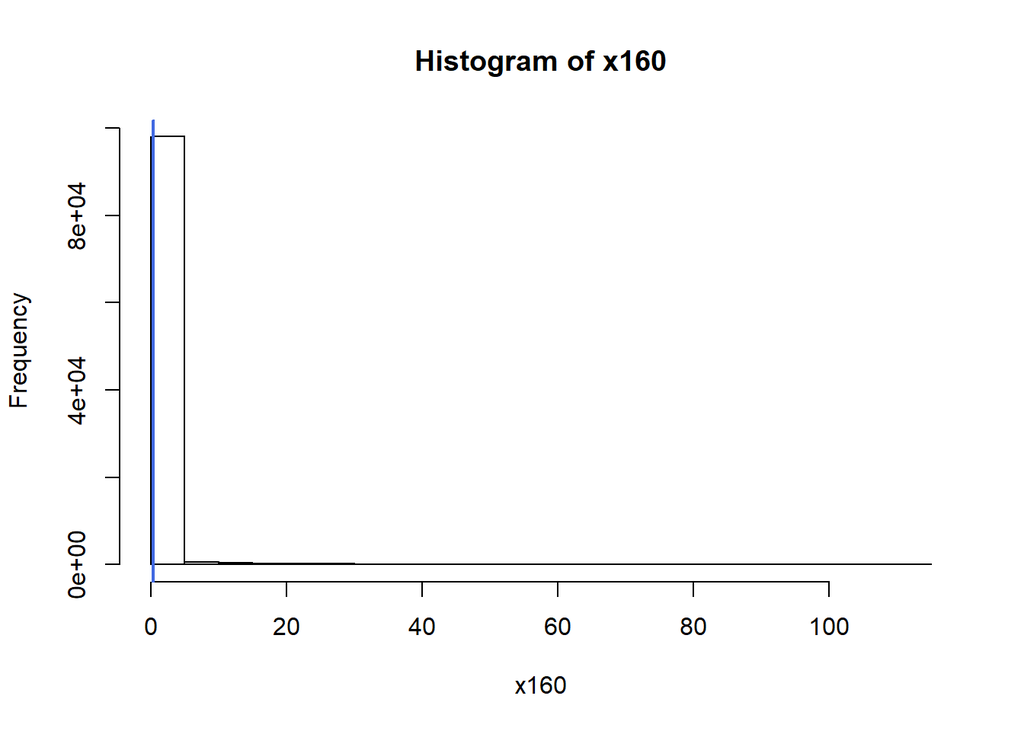

```r
##Now visualize the statistics
##Histogram

hist(data$x160,
    main = "Histogram of x160",
    xlab = "x160")
abline(v =mean(data$x160, na.rm = TRUE),col = "royalblue",
lwd = 2)
```

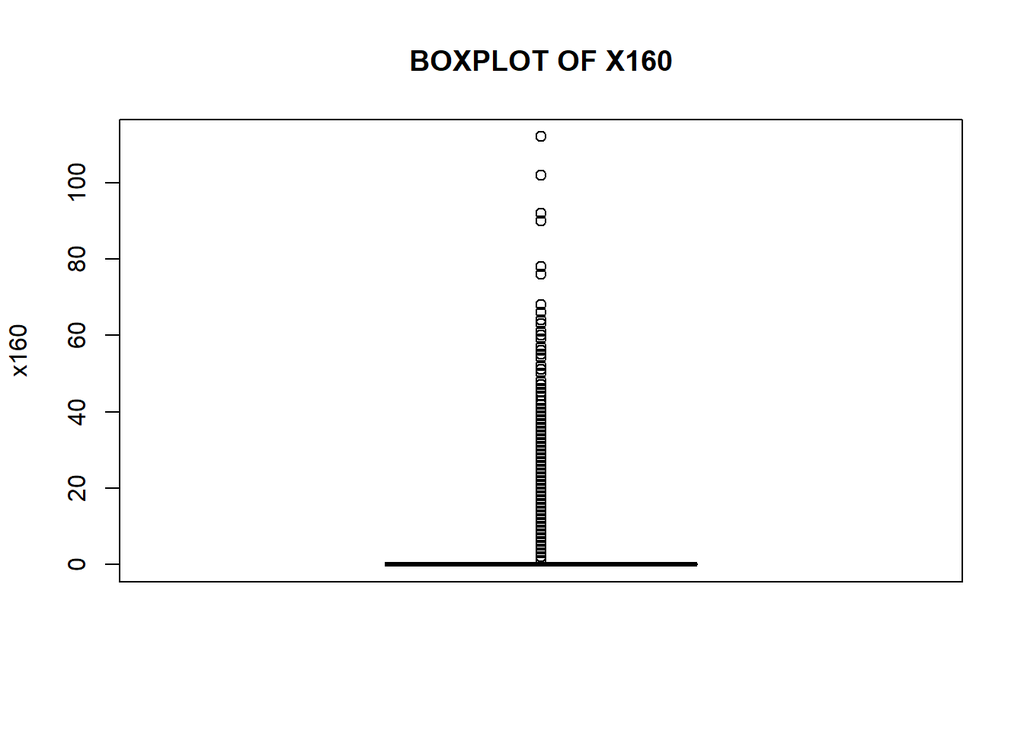

```r
##Boxplot
boxplot(data$x160,
       main = toupper("Boxplot of x160"),
       ylab = "x160",
       col = "blue")
```

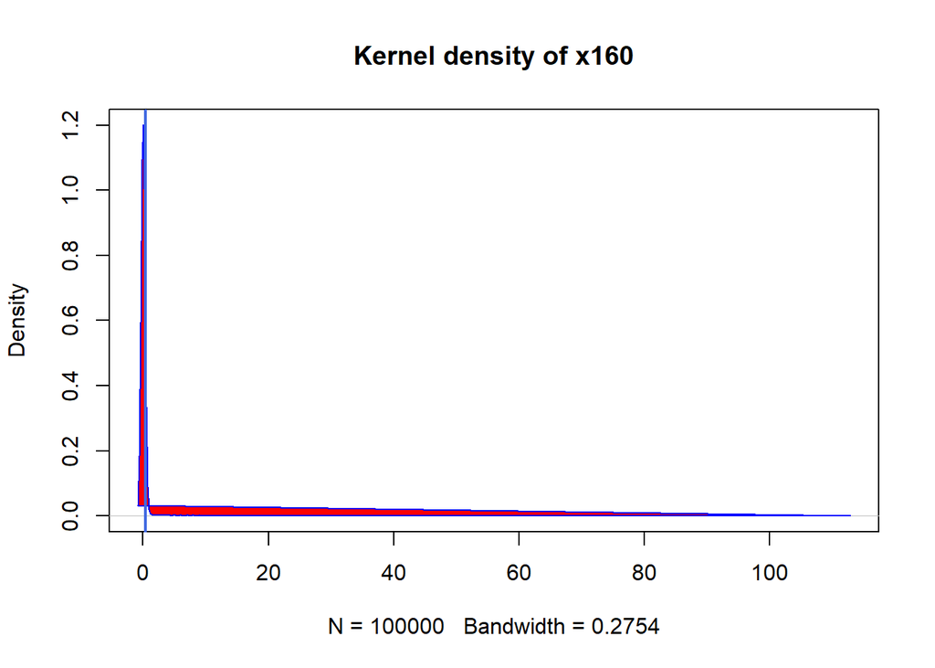

```r
##Density Plot
d <- density(data$x160, na.rm = TRUE)
plot(d, main = "Kernel density of x160")
polygon(d, col = "red", border = "blue")
abline(v =mean(data$x160, na.rm = TRUE),col = "royalblue",
lwd = 2)
```

## There is positive skewness in the data. There are no missing values. This variable have descrete values.